# Part II - View of Superstore Sales and Profit From Different Section.

## by Goodrich Okoro

## Investigation Overview

The objective is to view sales and profit in different categorical variables present in the data. In the process, we will know if any region is performing better than the other. Also to get more details about the state with loss.

I will start with the distribution of sales and profit, then proceed to the most ordered product. I will go on to check average sales and profit in each category and region after which we will see which customer segment is producing profit amongst the category. Then I will look at states that are generating loss.

## Dataset Overview

Dataset containing Sales & Profit of a Superstore. This dataset can be found on [Kaggle](https://www.kaggle.com/datasets/vivek468/superstore-dataset-final?select=Sample+-+Superstore.csv)

There are 9,994 entries of product ordered with 20 fields that give details about the product such as ship date, ship mode, region, product name, sales, quantity, profit, e.t.c.,There a five (5) categorical fields, ship mode being one of it is a ordered categorical type. Only four fields are numeric in nature, sales, quantity,discount, and profit.

## Sales Distribution

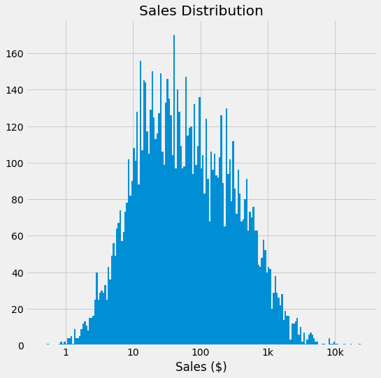

## Profit Distribution

Profit, when plotted on standard distribution, had a long tail on both positive and negative sides. I decided to focus on the positive profit generated and plot with a logarithmic scale. The plot took a unimodal shape with the highest peak below $50.

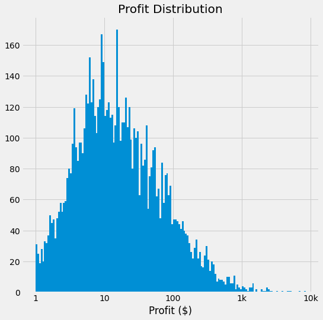

## Relationship between sales and profit

There is a positive and negative relationship between sales and profit. There are many product clusters in the positive side of profit, making a strong relationship, compared to the negative side meaning we have few losses. In the plot it is seen that the highest sale falls in the loss part of profit, thus we cannot say higher sales lead to high profit.

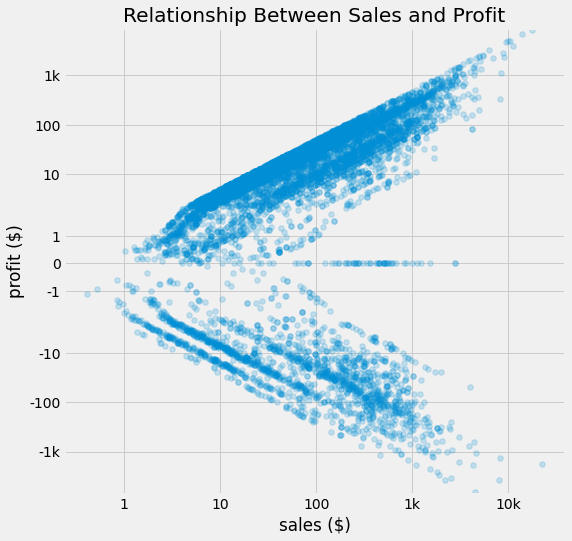

## Most purchased category across each region

Product from office supplies category is the most ordered product having the highest coming from the West region. South has the least ordered product, lowest coming from technology category.

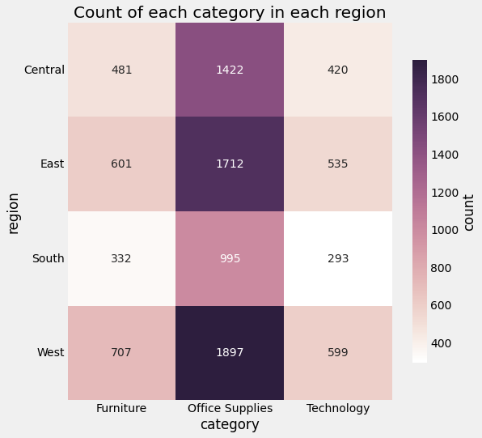

## Segment with most customers across each region.

When looking at the customer's segment, Consumers make the most purchase of product and Home Office the least with Corporate in-between. Customers from the consumers segment reside most in the west.

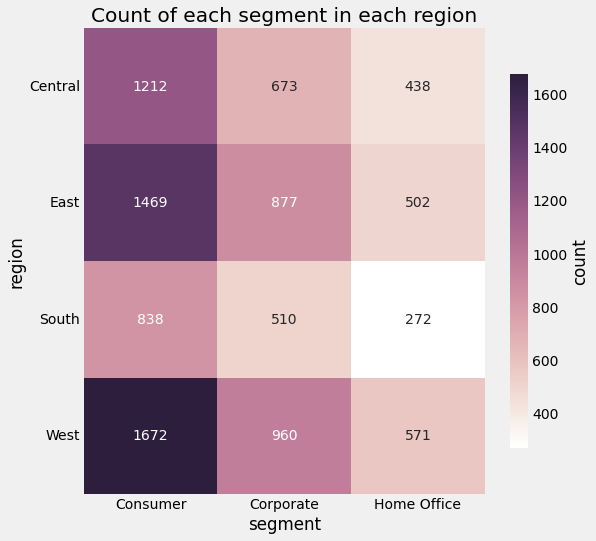

## Sub-category counts in each category.

It's obvious that each category has their own unique sub-category. Office Supplies is the most purchased product and it shows here that it has 9 unique sub-category which is 5 extra compared to other categories. The heatmap also shows that the least ordered product is Copiers from the technology category.

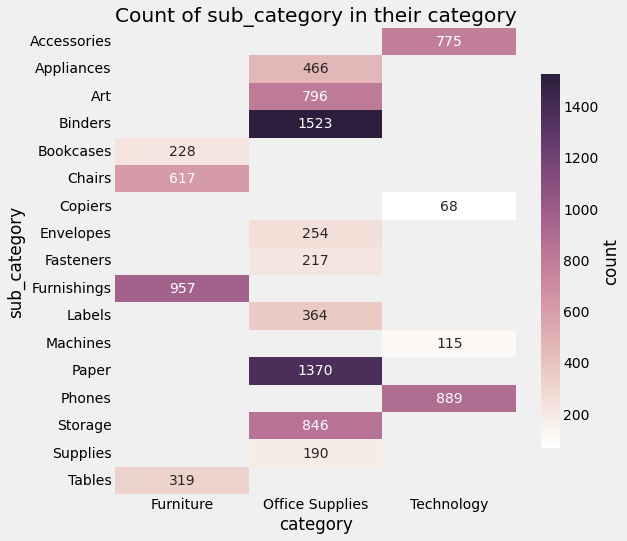

## Average sales made in each region

Products ordered by customers in the south are less compared to other regions but it generated the highest average sales. Central region made the lowest sale.

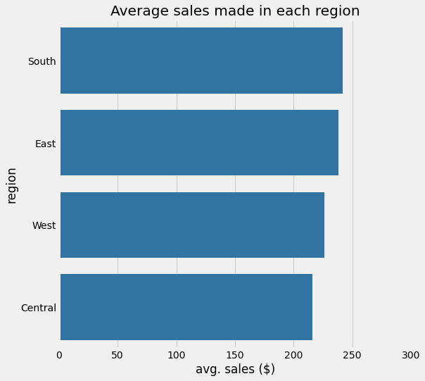

## Average profit made in each region.

Though South generated the highest sales, it did not produce much profit. Profit made in the central region is the lowest amongst the four regions.

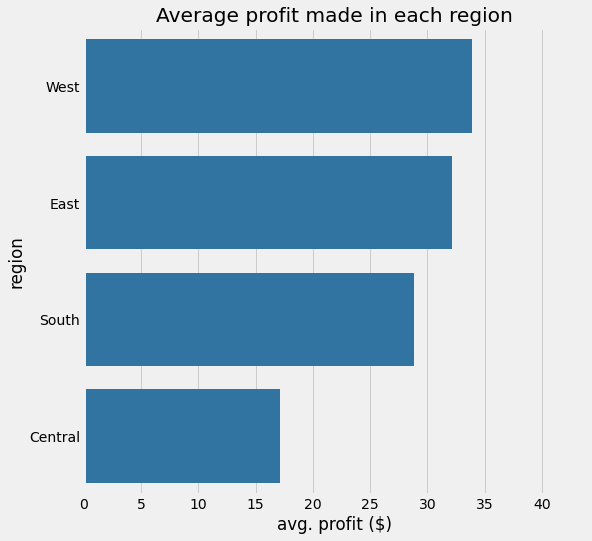

## Average sales made in each product category

Technology category made the highest sales (above average of \$400). Earlier on we saw that products in the office supplies category is the most ordered product, but it is clear here that it generated the least sales (average below $150)

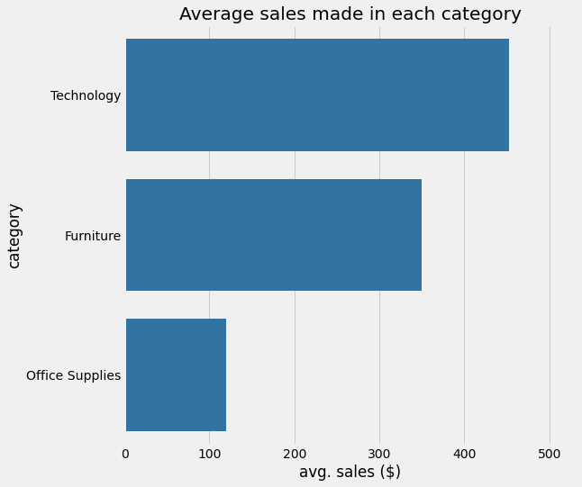

## Average profit made in each product category

Furniture made the least profit, far below an average of \$20. As we saw in the previous slide that Technology Category made the highest sale, here it shows that it also made the highest profit, over an average of $70.

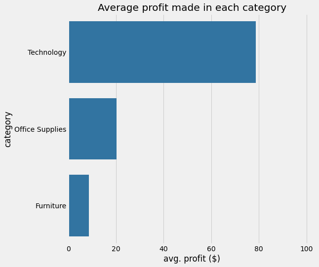

## States with loss (Negative Profit)

After exploring the data, I found out that ten (10) states made losses. Texas state made the highest while Oregon made the least.

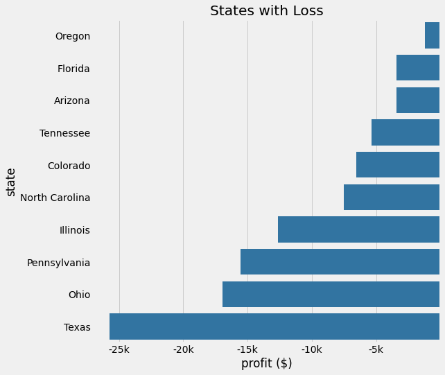

## Relationship between sales and profit showing product category.

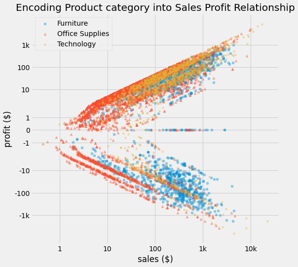

## Relationship between sales and profit showing product region.

There is much clustering of products ordered to the west in the sale range of \$100 to $1k.

Earlier on we saw that the highest sale made a loss, here we can see that the product was ordered by a customer in the south region. Later on we would know which segment the customer with this order belongs to.

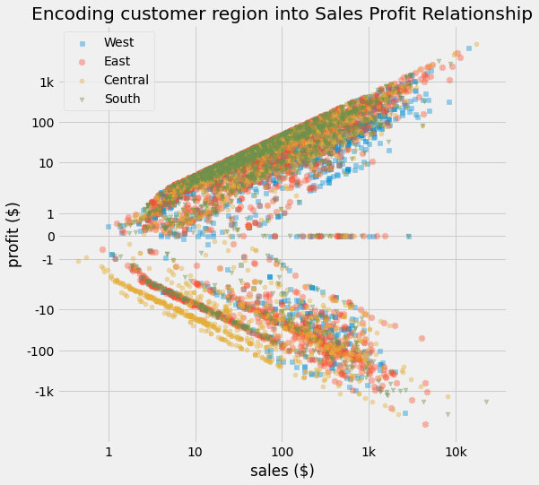

## Average sales in each category based on region

It looks like all the same average sales were made from the Furniture category in all regions, but the heatmap shows the exact value to clear the air. We can see that the highest sale (average of approximately $508) was made from Technology category in the South region followed by Technology category in the East region.

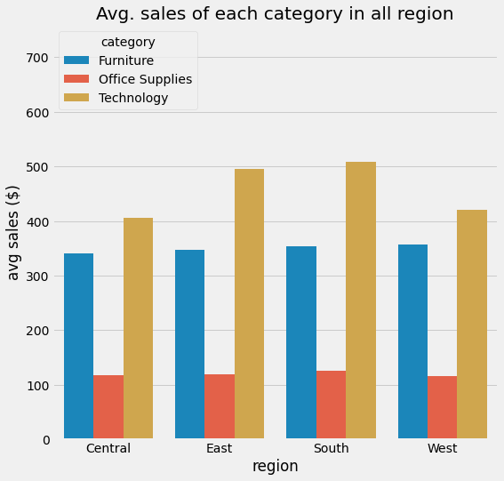

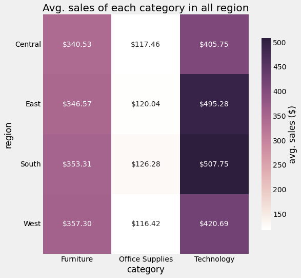

## Average profit in each category based on region

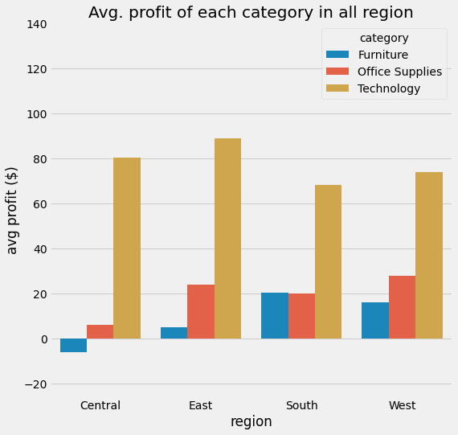

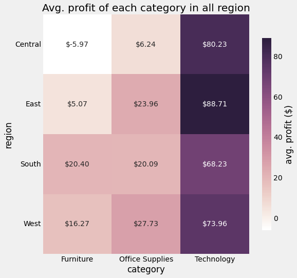

## Relationship between sales and profit considering only states with loss

Here we are seeing the relationship between sales and profit for a subset of the 10 states with loss. It's no surprise that there is much loss compared to profit.

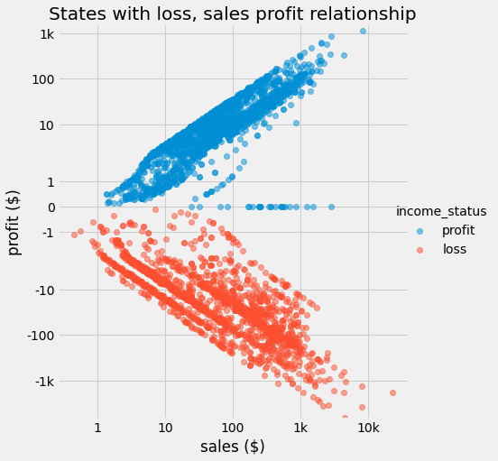

## Average sales from each customer's segment in all regions.

At this point we should not be surprised why the technology category keeps making the highest sales or profit. Here we see that customer's from the Home Office in the South contributed the most (produce average sales over $1k) to this.

Surprisingly, the technology category made the highest sales amongst all segments in each region except for Home Office in the east region and Corporate in the west region.

Office Supplies category made the lowest sale from all customer's segment in each region

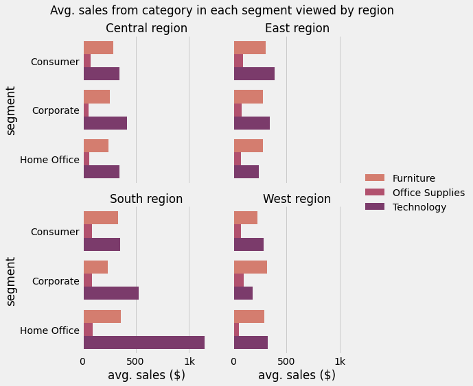

## Average profit from each customer's segment in all regions.

If you recall from the slide showing category then regions on sales profit relationship, it was noted that the product that made the highest sale which generated loss was of the Technology category ordered to the south. Looking at the south region, we can see that the customer who purchased this product belongs to the Corporate segment.

In the east region, no segment produced a profit from any of the categories.

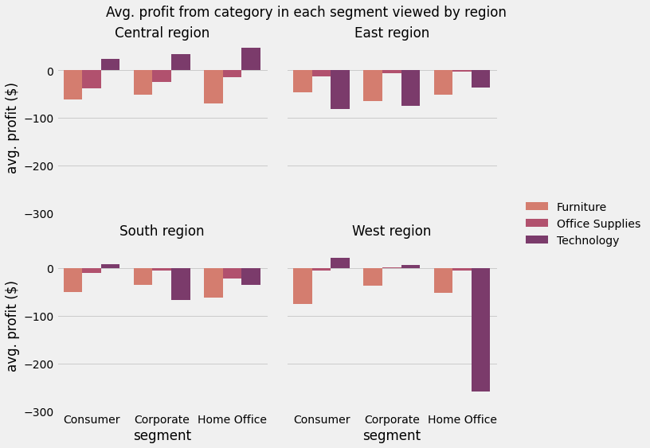

## Sales from product categories across states with loss.

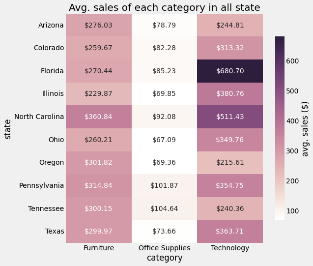

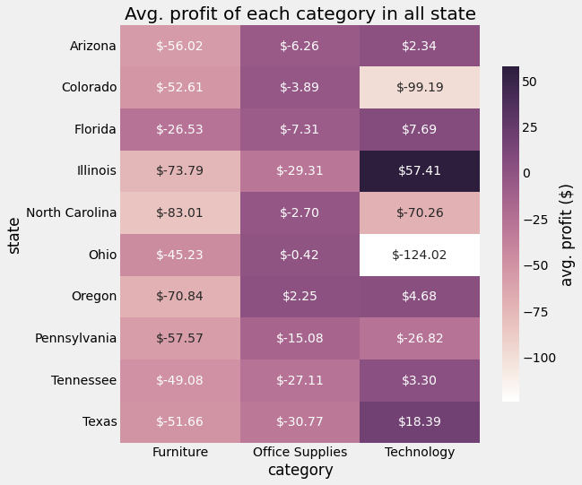